# Tutorial 04: Indirect Connectivity and Influence

Alexander Bates

2025-12-16

## Introduction

This tutorial introduces the **influence metric**, a measure of indirect connectivity developed and used in the [BANC paper](https://www.biorxiv.org/content/10.1101/2024.12.28.630584v1) (Eckstein et al., 2025).

### What is Influence?

While direct synaptic connections tell us which neurons are connected, they don’t capture the full picture of how signals propagate through neural circuits. The influence metric quantifies how strongly a neuron or group of neurons can affect downstream targets through both direct and indirect pathways.

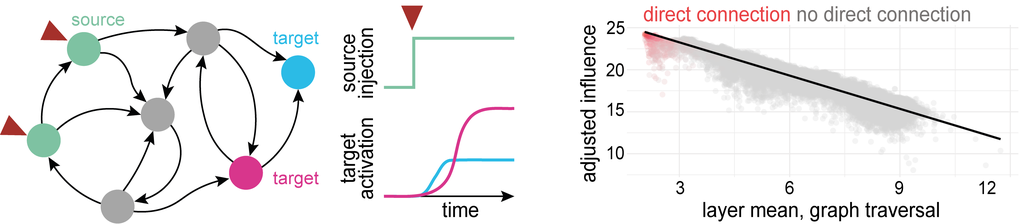

### How It Works

The influencer package implements a linear dynamical model of neural signal propagation:

**Model equation:** τ dr(t)/dt = (W - I)r(t) + s(t)

Where: - **r(t)** = neural activity vector - **W** = connectivity matrix (scaled by synapse counts) - **s(t)** = stimulation input to seed neurons - **τ** = time constant

At steady state, the influence score equals:

**r∞ = -(W̃ - I)⁻¹s**

Where W̃ is rescaled to ensure network stability. Results are log-transformed with a constant (+24) to produce “adjusted influence” scores above zero.

### Key Advantages

1. **Captures indirect effects**: Quantifies multi-synaptic pathways
2. **Accounts for network structure**: Considers convergent and divergent connections
3. **Computationally efficient**: Uses sparse matrix decomposition with caching for repeated calculations
4. **Biologically validated**: Correlates with optogenetic activation experiments

**Currently working with dataset:** banc_746 **Data location:** gs://brain-and-nerve-cord_exports/processed_data (Google Cloud Storage)

One way in which we can use these indirect measures, is to understand how sensory neurons from across the body, and effector neuron that project across the body, relate to other neurons of the central nervous system.

This can help us interpret what “deeper” neurons “care” about, or what behaviours they may inform.

As a reminder, sensory and effector neurons, our `cell_class` and `cell_sub_class` labels can tell us about innervation of exterior body parts.

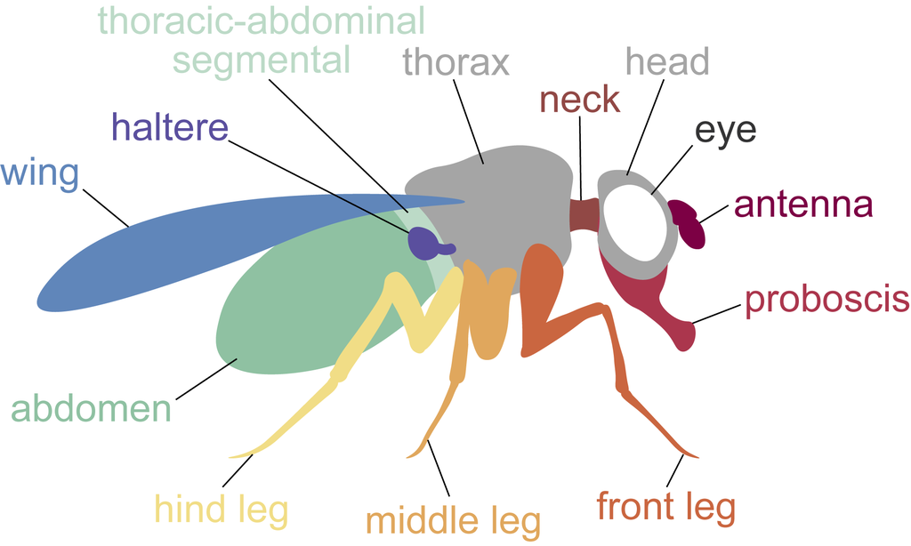

As well as internal ones.

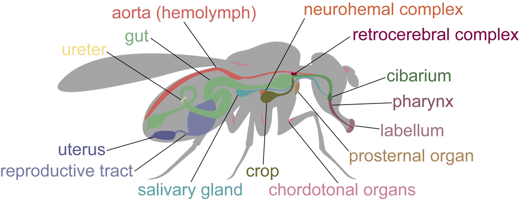

# Core tutorial

## Setup and Load Data

Make sure `influencer` is installed, and that you have installed what we need for the python backend, with: `install_python_influence_calculator()` (should just need to run once).

First, we need to our data:

```r
# Setup GCS access if needed
if (use_gcs) {
  setup_gcs_access()
}
```

```
## Setting up GCS access...
## Using conda Python environment...
## ✓ GCS access configured
## ✓ Python warnings suppressed
```

```r
# Load metadata
meta_path <- construct_path(data_path, dataset, "meta")
meta <- read_feather_gcs(meta_path, use_gcs = use_gcs)
```

```
## Authenticating with Google Cloud Storage...
## Reading from GCS: gs://brain-and-nerve-cord_exports/processed_data/banc/banc_746_meta.feather
## Downloaded 9.84 MB from GCS
## Loading into memory with Arrow...
## ✓ Done! Loaded 168791 rows
```

```r
# Load edgelist
edgelist_path <- construct_path(data_path, dataset, "edgelist_simple")
edgelist_simple <- read_feather_gcs(edgelist_path, use_gcs = use_gcs)
```

```
## Authenticating with Google Cloud Storage...
## Reading from GCS: gs://brain-and-nerve-cord_exports/processed_data/banc/banc_746_simple_edgelist.feather
## Downloaded 3429.91 MB from GCS
## Loading into memory with Arrow...
## ✓ Done! Loaded 113981973 rows
```

```r
# Show edgelist structure
cat("\nEdgelist columns:", paste(colnames(edgelist_simple), collapse = ", "), "\n")
```

```
##
## Edgelist columns: pre, post, count, norm, total_input
```

```r
head(edgelist_simple, 3)
```

```
## # A tibble: 3 × 5
##   pre                post               count  norm total_input
##   <chr>              <chr>              <int> <dbl>       <int>
## 1 720575941509220642 720575941277394247     1   1             1
## 2 720575941526837604 720575940420901192     1   1             1
## 3 720575941508750721 720575941576493706     1   0.5           2
```

## Filter Strong Connections

To speed up influence calculations, we filter out weak connections (fewer than 5 synapses):

```r
# Filter for connections with at least 5 synapses
edgelist_filtered <- edgelist_simple %>%
  filter(count >= 5)
cat("Original connections:", nrow(edgelist_simple), "\n")
```

```
## Original connections: 113981973
```

```r
cat("After filtering (≥5 synapses):", nrow(edgelist_filtered), "\n")
```

```
## After filtering (≥5 synapses): 1953550
```

```r
cat("Retained:", round(100 * nrow(edgelist_filtered) / nrow(edgelist_simple), 1), "%\n")
```

```
## Retained: 1.7 %
```

## Example 1: Sensory Influence on Dopaminergic Neurons

Let’s examine how sensory neurons influence mushroom body dopaminergic neurons. This is biologically relevant because:

- Dopaminergic neurons provide **teaching signals** for associative memory
- They are hypothesised to receive unconditioned sensory information
- **PAM** dopamine neurons are involved in appetitive (reward) learning
- **PPL1** dopamine neurons are involved in aversive (punishment) learning

### Define Source and Target Neurons

```r
# Source: All sensory neurons (afferent flow)
sensory_neurons <- meta %>%
  filter(flow == "afferent") %>%
  distinct(!!sym(dataset_id), cell_sub_class, cell_type)
cat("Found", nrow(sensory_neurons), "sensory neurons\n")
```

```
## Found 15462 sensory neurons
```

```r
# Get unique sensory sub-classes
sensory_sub_classes <- sensory_neurons %>%
  pull(cell_sub_class) %>%
  unique() %>%
  sort()
cat("Sensory sub-classes (n=", length(sensory_sub_classes), "):\n")
```

```
## Sensory sub-classes (n= 109 ):
```

```r
cat(paste(head(sensory_sub_classes, 10), collapse = ", "), "\n\n")
```

```
## abdomen_multidendritic_neuron, abdomen_orphan_neuron, abdomen_oxygenation_neuron, abdomen_strand_neuron, abdominal_ppk_neuron, abdominal_terminalia_bristle, abdominal_wall_multidendritic_neuron, antenna_bristle_neuron, antenna_campaniform_sensillum_neuron, antenna_hygrosensory_receptor_neuron
```

```r
# Target: All mushroom body dopaminergic neurons
mb_dopamine_neurons <- meta %>%
  filter(cell_class == "mushroom_body_dopaminergic_neuron") %>%
  distinct(!!sym(dataset_id), cell_sub_class, cell_type)
cat("Found", nrow(mb_dopamine_neurons), "mushroom body dopamine neurons\n")
```

```
## Found 255 mushroom body dopamine neurons
```

```r
# Get unique MB dopamine types
mb_da_types <- mb_dopamine_neurons %>%
  pull(cell_type) %>%
  unique() %>%
  sort()
cat("MB dopamine types (n=", length(mb_da_types), "):\n")
```

```
## MB dopamine types (n= 35 ):
```

```r
cat(paste(head(mb_da_types, 10), collapse = ", "), "\n")
```

```
## PAM01, PAM01_b, PAM02, PAM03, PAM04, PAM04_a, PAM05, PAM06, PAM06_b, PAM07
```

### Set Up Influence Calculator

```r
# Prepare data for influencer package
# The Python influencer package expects specific formats:
# - edgelist with pre, post, count (or norm) columns
# - meta with root_id column

# Check edgelist column names
edgelist_cols <- colnames(edgelist_filtered)
cat("Edgelist columns:", paste(edgelist_cols, collapse = ", "), "\n")
```

```
## Edgelist columns: pre, post, count, norm, total_input
```

```r
# Determine pre/post column names and rename if needed
if ("pre" %in% edgelist_cols && "post" %in% edgelist_cols) {
  edgelist_for_ic <- edgelist_filtered
} else {
  # Need to rename columns
  pre_col <- paste0("pre_", dataset_id)
  post_col <- paste0("post_", dataset_id)

  edgelist_for_ic <- edgelist_filtered %>%
    rename(
      pre = !!sym(pre_col),
      post = !!sym(post_col)
    )
}

# Prepare metadata with root_id column
meta_for_ic <- meta %>%
  rename(root_id = !!sym(dataset_id))
cat("  Edgelist:", nrow(edgelist_for_ic), "connections\n")
```

```
##   Edgelist: 1953550 connections
```

```r
cat("  Metadata:", nrow(meta_for_ic), "neurons\n\n")
```

```
##   Metadata: 168791 neurons
```

```r
# Initialize the influence calculator
# This uses the Python backend (ConnectomeInfluenceCalculator)
ic_dataset <- influence_calculator_py(
  edgelist_simple = edgelist_for_ic,
  meta = meta_for_ic
)
```

### Calculate Influence Scores

Now we calculate influence scores from each sensory sub-class to all MB dopaminergic neurons:

```r
cat("Note: This will take time - influence calculations involve matrix operations on the full network\n\n")
```

```
## Note: This will take time - influence calculations involve matrix operations on the full network
```

```r
# Get MB dopamine neuron IDs for filtering
mb_dopamine_ids <- mb_dopamine_neurons %>%
  pull(!!sym(dataset_id))

# Calculate influence for each sensory sub-class
all_influence_scores_list <- list()

for (i in seq_along(sensory_sub_classes)) {
  sensory_sub_class <- sensory_sub_classes[i]

  # Progress indicator
  if (i %% 5 == 0 || i == length(sensory_sub_classes)) {
  }

  # Get IDs for this sensory sub-class
  sensory_ids <- sensory_neurons %>%
    filter(cell_sub_class == sensory_sub_class) %>%
    pull(!!sym(dataset_id))

  # Skip if no neurons found
  if (length(sensory_ids) == 0) next

  # Calculate influence from this sensory sub-class
  # calculate_influence_py returns a data frame with columns:
  # - root_id: target neuron ID
  # - Influence_score_(unsigned): raw influence score
  # - adjusted_influence: log-transformed influence (more interpretable)
  influence_scores <- calculate_influence_py(ic_dataset, sensory_ids) %>%
    filter(id %in% mb_dopamine_ids) %>%
    left_join(
      meta %>%
        distinct(!!sym(dataset_id), .keep_all = TRUE) %>%
        select(id = !!sym(dataset_id), target_class = cell_sub_class, target_type = cell_type),
      by = "id"
    ) %>%
    mutate(source = sensory_sub_class)

  all_influence_scores_list[[sensory_sub_class]] <- influence_scores
}

# Combine all results
all_influence_scores <- bind_rows(all_influence_scores_list)

# Show sample of results
all_influence_scores %>%
  select(source, id, `Influence_score_(unsigned)`, adjusted_influence, target_type) %>%
  head(10)
```

```
##                           source                 id Influence_score_(unsigned)
## 1  abdomen_multidendritic_neuron 720575941477857076               4.367597e-05
## 2  abdomen_multidendritic_neuron 720575941536157930               2.102865e-05
## 3  abdomen_multidendritic_neuron 720575941527558500               8.428382e-06
## 4  abdomen_multidendritic_neuron 720575941445894826               3.925197e-06
## 5  abdomen_multidendritic_neuron 720575941689127692               3.478212e-05
## 6  abdomen_multidendritic_neuron 720575941552246783               1.998037e-05
## 7  abdomen_multidendritic_neuron 720575941685802735               5.199819e-08
## 8  abdomen_multidendritic_neuron 720575941430216073               4.897231e-08
## 9  abdomen_multidendritic_neuron 720575941596156965               2.240533e-06
## 10 abdomen_multidendritic_neuron 720575941655019732               5.681189e-06
##    adjusted_influence target_type
## 1           13.961287      PPL102
## 2           13.230375      PPL108
## 3           12.316094      PPL103
## 4           11.551906       PAM02
## 5           13.733593      PPL101
## 6           13.179240      PPL101
## 7            7.227943       PAM06
## 8            7.167989       PAM02
## 9           10.991203      PPL107
## 10          11.921650      PPL202
```

### Aggregate by Cell Type

```r
# Aggregate influence scores by source and target cell type
all_influence_scores_ct <- all_influence_scores %>%
  left_join(meta %>%
              distinct(cell_sub_class, .keep_all = TRUE) %>%
              select(source=cell_sub_class, source_class = cell_class),
            by="source") %>%
  group_by(source_class, target_type) %>%
   summarise(
    influence = sum(`Influence_score_(unsigned)`, na.rm = TRUE),
    adjusted_influence = log(sum(influence, na.rm = TRUE))+24,
    adjusted_influence = ifelse(is.infinite(adjusted_influence),0,adjusted_influence),
    n_targets = n(),
    .groups = "drop"
  ) %>%
  filter(!is.na(target_type), !is.na(source_class))

# Show top influences
all_influence_scores_ct %>%
  arrange(desc(adjusted_influence)) %>%
  select(source_class, target_type, adjusted_influence, n_targets) %>%
  head(10)
```

```
## # A tibble: 10 × 4
##    source_class                    target_type adjusted_influence n_targets
##    <chr>                           <chr>                    <dbl>     <int>
##  1 olfactory_receptor_neuron       PPL202                    21.0         4
##  2 olfactory_receptor_neuron       PPL201                    20.4         6
##  3 olfactory_receptor_neuron       PAM07                     20.0        14
##  4 hygrosensory_receptor_neuron    PPL202                    19.6         2
##  5 internal_taste_sensillum_neuron PAM11                     19.4        12
##  6 olfactory_receptor_neuron       PPL203                    19.4         2
##  7 thermosensory_receptor_neuron   PPL203                    19.1         2
##  8 olfactory_receptor_neuron       PAM02                     19.1        26
##  9 olfactory_receptor_neuron       PAM05                     19.0        24
## 10 thermosensory_receptor_neuron   PPL202                    19.0         4
```

## Visualisation: Influence Heatmap

```r
# Create a matrix for heatmap
influence_matrix <- all_influence_scores_ct %>%
  select(source_class, target_type, adjusted_influence) %>%
  pivot_wider(names_from = target_type, values_from = adjusted_influence, values_fill = 0) %>%
  column_to_rownames("source_class") %>%
  as.matrix()
influence_matrix[is.na(influence_matrix)] <- 0
influence_matrix[is.infinite(influence_matrix)] <- 0
influence_matrix <- influence_matrix[rowSums(influence_matrix)>100,]

# We want to ask what the most prominent influences onto DANs is
# So we can minmax normalise influence_matrix
influence_matrix_norm <- apply(X = influence_matrix, MARGIN = 2, FUN = function(x) (x-min(x,na.rm=TRUE))/(max(x,na.rm=TRUE)-min(x,na.rm=TRUE)))
influence_matrix_norm[is.infinite(influence_matrix_norm)] <- 0
influence_matrix_norm[is.na(influence_matrix_norm)] <- 0

# Create static heatmap with pheatmap (saved to PNG)
pheatmap(
  influence_matrix_norm,
  clustering_method = "ward.D2",
  # color = colorRampPalette(c("navy", "blue", "cyan", "yellow", "orange", "red"))(256),
  show_rownames = TRUE,
  show_colnames = TRUE,
  main = "Sensory Influence on MB Dopaminergic Neurons",
  filename = file.path(img_dir, paste0(dataset, "_influence_heatmap.png")),
  width = 10,
  height = 10
)

# Create interactive heatmap with Ward's clustering (no dendrograms shown)
p_influence_heatmap <- heatmaply(
  influence_matrix_norm,
  dendrogram = "none",
  hclust_method = "ward.D2",
  #colors = colorRampPalette(c("navy", "blue", "cyan", "yellow", "orange", "red"))(256),
  main = "Sensory Influence on MB Dopaminergic Neurons",
  xlab = "Target: MB Dopamine Neuron Type",
  ylab = "Source: Sensory Sub-Class",
  showticklabels = c(TRUE, TRUE),
  hide_colorbar = FALSE,
  fontsize_row = 8,
  fontsize_col = 8,
  key.title = "Normalized\nInfluence"
)

p_influence_heatmap
```

[interactive chart not shown]

## Visualisation: UMAP of Influence Patterns

We can also visualise the influence patterns using UMAP, where each point is a dopaminergic neuron:

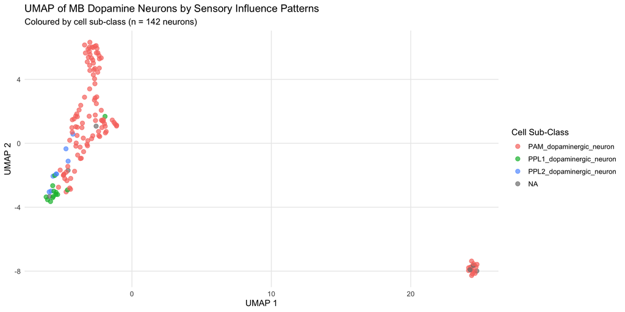

```r
# Aggregate influence by individual neuron
all_influence_scores_n <- all_influence_scores %>%
  group_by(source, id) %>%
   summarise(
    influence = sum(`Influence_score_(unsigned)`, na.rm = TRUE),
    adjusted_influence = log(sum(influence, na.rm = TRUE))+24,
    adjusted_influence = ifelse(is.infinite(adjusted_influence),0,adjusted_influence),
    target_type = first(target_type),
    target_class = first(target_class),
    .groups = "drop"
  ) %>%
  filter(!is.na(id), !is.na(source))

# Create matrix: rows = neurons, columns = sensory sub-classes
influence_matrix_umap <- all_influence_scores_n %>%
  select(id, source, adjusted_influence) %>%
  pivot_wider(names_from = source, values_from = adjusted_influence, values_fill = 0) %>%
  column_to_rownames("id") %>%
  as.matrix()

# Run UMAP (explicitly use umap package, not uwot)
set.seed(42)
umap_result <- umap::umap(influence_matrix_umap, n_neighbors = 15, min_dist = 0.1)

# Create data frame for plotting
umap_df <- data.frame(
  id = rownames(influence_matrix_umap),
  UMAP1 = umap_result$layout[, 1],
  UMAP2 = umap_result$layout[, 2]
) %>%
  left_join(
    meta %>%
      distinct(!!sym(dataset_id), .keep_all = TRUE) %>%
      select(id = !!sym(dataset_id), cell_type, cell_sub_class, cell_class),
    by = "id"
  )

# Plot by cell sub-class
p_umap_subclass <- ggplot(umap_df, aes(x = UMAP1, y = UMAP2, color = cell_sub_class)) +
  geom_point(alpha = 0.7, size = 2.5) +
  labs(
    title = "UMAP of MB Dopamine Neurons by Sensory Influence Patterns",
    subtitle = paste("Coloured by cell sub-class (n =", nrow(umap_df), "neurons)"),
    x = "UMAP 1",
    y = "UMAP 2",
    color = "Cell Sub-Class"
  ) +
  theme_minimal(base_size = 12) +
  theme(
    legend.position = "right",
    panel.grid.minor = element_blank()
  )

print(p_umap_subclass)
```

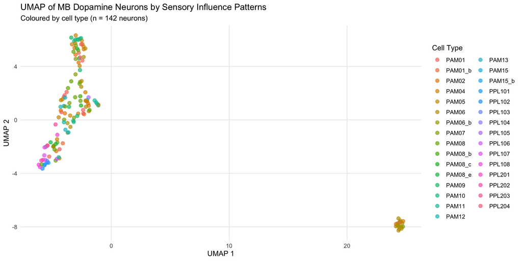

```r
save_plot(p_umap_subclass, paste0(dataset, "_influence_umap_subclass"))

# Plot by cell type
p_umap_type <- ggplot(umap_df, aes(x = UMAP1, y = UMAP2, color = cell_type)) +
  geom_point(alpha = 0.7, size = 2.5) +
  labs(
    title = "UMAP of MB Dopamine Neurons by Sensory Influence Patterns",
    subtitle = paste("Coloured by cell type (n =", nrow(umap_df), "neurons)"),
    x = "UMAP 1",
    y = "UMAP 2",
    color = "Cell Type"
  ) +
  theme_minimal(base_size = 12) +
  theme(
    legend.position = "right",
    panel.grid.minor = element_blank()
  )
save_plot(p_umap_type, paste0(dataset, "_influence_umap_type"))
print(p_umap_type)
```

# Extensions

Below are more involved analyses, with longer compute times. Working through these will show you how to think about sensory and effector influence together, plot a UMAP based on influence scores, and interpret the biology of our results.

## Extension 1: Specific olfactory channel influence onto pC1 neurons in BANC and maleCNS

pC1 neurons are a small cluster of sexually dimorphic, doublesex/fruitless-positive neurons in the Drosophila central brain that act as a hub for integrating social cues and controlling sex-specific internal state and behavior. In the male literature they are often referred to as the P1 cluster; in both sexes they sit at the top of a hierarchy that gates courtship, aggression, and related states.

Since BANC is a female nervous system and maleCNs is a male one, we can directly compare information flow onto this sexually dimorphic type, and compare.

We are interested in seeing which antennal lobe glomeruli (olfactory and thermosensory), and which gustatory neuron cell sub classes influence pC1 neurons, in both data sets.

First let’s read the BANC and maleCNS metadata, and select our pC1 neuron by doing a regex search of “pC1” on the `cell_type` column.

```r
# Data set 1: BANC (female)
dataset1 <- "banc_746"
dataset_id1 <- "banc_746_id"
meta_path1 <- construct_path(data_path, dataset1, "meta")
meta1 <- read_feather_gcs(meta_path1, use_gcs = use_gcs) %>%
  rename(root_id = !!sym(dataset_id1))
```

```
## Authenticating with Google Cloud Storage...
## Reading from GCS: gs://brain-and-nerve-cord_exports/processed_data/banc/banc_746_meta.feather
## Downloaded 9.84 MB from GCS
## Loading into memory with Arrow...
## ✓ Done! Loaded 168791 rows
```

```r
edgelist_path1 <- construct_path(data_path, dataset1, "edgelist_simple")
edgelist_simple1 <- read_feather_gcs(edgelist_path1, use_gcs = use_gcs) %>%
  filter(norm >= 0.0001)
```

```
## Authenticating with Google Cloud Storage...
## Reading from GCS: gs://brain-and-nerve-cord_exports/processed_data/banc/banc_746_simple_edgelist.feather
## Downloaded 3429.91 MB from GCS
## Loading into memory with Arrow...
## ✓ Done! Loaded 113981973 rows
```

```r
# Data set 2: maleCNS (male)
dataset2 <- "malecns_09"
dataset_id2 <- "malecns_09_id"
meta_path2 <- construct_path(data_path, dataset2, "meta")
meta2 <- read_feather_gcs(meta_path2, use_gcs = use_gcs) %>%
  rename(root_id = !!sym(dataset_id2))
```

```
## Authenticating with Google Cloud Storage...
## Reading from GCS: gs://brain-and-nerve-cord_exports/processed_data/malecns/malecns_09_meta.feather
## Downloaded 12.23 MB from GCS
## Loading into memory with Arrow...
## ✓ Done! Loaded 165114 rows
```

```r
edgelist_path2 <- construct_path(data_path, dataset2, "edgelist_simple")
edgelist_simple2 <- read_feather_gcs(edgelist_path2, use_gcs = use_gcs) %>%
  filter(norm >= 0.0001)
```

```
## Authenticating with Google Cloud Storage...
## Reading from GCS: gs://brain-and-nerve-cord_exports/processed_data/malecns/malecns_09_simple_edgelist.feather
## Downloaded 1557.85 MB from GCS
## Loading into memory with Arrow...
## ✓ Done! Loaded 142881142 rows
```

We can then prime our edgelists for influence score calculation, pruning out weak connections, this time taking `norm>=0.0001`. We think `norm` will be a bit more similar between datasets, `count` may vary more.

```r
# Initialize influence calculators
ic_dataset1 <- influence_calculator_py(
  edgelist_simple = edgelist_simple1,
  meta = meta1
)
ic_dataset2 <- influence_calculator_py(
  edgelist_simple = edgelist_simple2,
  meta = meta2
)
```

Now let’s calculate influence scores from all cell types starting with `^ORN|^THRN|^HRN`, and all cell types which match for `gustatory` in `cell_function`.

```r
# Dataset 1 (BANC): Find pC1 neurons and sensory neurons
pc1_meta1 <- meta1 %>%
  filter(grepl("^pC1|^P1_", cell_type, ignore.case = TRUE))
sens_meta1 <- meta1 %>%
  filter(
    !is.na(cell_type),
    grepl("sensory",super_class),
    !grepl("^IN|^MN",cell_type),
    grepl("^ORN|^THRN|^HRN|^TRN", cell_type) |
    grepl("gustatory", cell_function, ignore.case = TRUE)
  ) %>%
  distinct(cell_type, .keep_all = TRUE)

# Dataset 2 (maleCNS): Find pC1 neurons and sensory neurons
pc1_meta2 <- meta2 %>%
  filter(grepl("^pC1|^P1_", cell_type, ignore.case = TRUE))
sens_meta2 <- meta2 %>%
  filter(
    !is.na(cell_type),
    grepl("sensory",super_class),
    !grepl("^IN|^MN",cell_type),
    grepl("^ORN|^THRN|^HRN|^TRN", cell_type) |
    grepl("gustatory", cell_function, ignore.case = TRUE)
  ) %>%
  distinct(cell_type, .keep_all = TRUE)

# Get pC1 neuron IDs for filtering
pc1_ids1 <- pc1_meta1 %>% pull(root_id)
pc1_ids2 <- pc1_meta2 %>% pull(root_id)

# Calculate influence from each sensory cell type to pC1 neurons
# Dataset 1 (BANC)
pc1_influence_list1 <- list()

for (i in seq_len(nrow(sens_meta1))) {
  sensory_type <- sens_meta1$cell_type[i]

  # Get all neurons of this cell type
  sensory_ids <- meta1 %>%
    filter(cell_type == sensory_type) %>%
    pull(root_id)

  if (length(sensory_ids) == 0) next

  if (i %% 10 == 0 || i == nrow(sens_meta1)) {
  }

  # Calculate influence
  influence_scores <- calculate_influence_py(ic_dataset1, sensory_ids) %>%
    filter(id %in% pc1_ids1) %>%
    mutate(
      source_type = sensory_type,
      dataset = "BANC"
    ) %>%
    left_join(
      pc1_meta1 %>% select(id = root_id, target_type = cell_type),
      by = "id"
    )

  pc1_influence_list1[[sensory_type]] <- influence_scores
}

pc1_influence1 <- bind_rows(pc1_influence_list1)

# Dataset 2 (maleCNS)
pc1_influence_list2 <- list()

for (i in seq_len(nrow(sens_meta2))) {
  sensory_type <- sens_meta2$cell_type[i]

  # Get all neurons of this cell type
  sensory_ids <- meta2 %>%
    filter(cell_type == sensory_type) %>%
    pull(root_id)

  if (length(sensory_ids) == 0) next

  if (i %% 10 == 0 || i == nrow(sens_meta2)) {
  }

  # Calculate influence
  influence_scores <- calculate_influence_py(ic_dataset2, sensory_ids) %>%
    filter(id %in% pc1_ids2) %>%
    mutate(
      source_type = sensory_type,
      dataset = "maleCNS"
    ) %>%
    left_join(
      pc1_meta2 %>% select(id = root_id, target_type = cell_type),
      by = "id"
    )

  pc1_influence_list2[[sensory_type]] <- influence_scores
}

pc1_influence2 <- bind_rows(pc1_influence_list2)

# Combine both datasets
pc1_influence_all <- bind_rows(pc1_influence1, pc1_influence2)
cat("\nTotal influence scores:", nrow(pc1_influence_all), "\n")
```

```
##
## Total influence scores: 21840
```

```r
cat("Unique sensory types in BANC:", length(unique(pc1_influence1$source_type)), "\n")
```

```
## Unique sensory types in BANC: 117
```

```r
cat("Unique sensory types in maleCNS:", length(unique(pc1_influence2$source_type)), "\n")
```

```
## Unique sensory types in maleCNS: 134
```

We can now visualise two heatmaps, one for BANC and one for maleCNS, of chemosensory influence onto pC1 neurons by cell type, and identify the sensory channels that matter most to them.

```r
# Aggregate influence by source and target cell type
pc1_influence_ct <- pc1_influence_all %>%
  group_by(dataset, source_type, target_type) %>%
  summarise(
    influence = sum(`Influence_score_(unsigned)`, na.rm = TRUE),
    adjusted_influence = log(sum(influence, na.rm = TRUE)) + 24,
    adjusted_influence = ifelse(is.infinite(adjusted_influence),0,adjusted_influence),
    n_connections = n(),
    .groups = "drop"
  ) %>%
  filter(!is.na(source_type), !is.na(target_type))

# Create separate matrices for each dataset
create_pc1_matrix <- function(data, dataset_name) {
  matrix_data <- data %>%
    filter(dataset == dataset_name) %>%
    select(source_type, target_type, adjusted_influence) %>%
    pivot_wider(
      names_from = target_type,
      values_from = adjusted_influence,
      values_fill = 0
    ) %>%
    column_to_rownames("source_type") %>%
    as.matrix()

  # Clean matrix
  matrix_data[is.na(matrix_data)] <- 0
  matrix_data[is.infinite(matrix_data)] <- 0
  matrix_data <- matrix_data[rowSums(matrix_data)>50,]

  # Filter rows with minimal influence
  if (nrow(matrix_data) > 0) {
    matrix_data <- matrix_data[rowSums(matrix_data) > 10, , drop = FALSE]
  }

  return(matrix_data)
}

# Create matrices
pc1_matrix1 <- create_pc1_matrix(pc1_influence_ct, "BANC")
pc1_matrix2 <- create_pc1_matrix(pc1_influence_ct, "maleCNS")

# Min-max normalize by column (per pC1 target type)
normalize_matrix <- function(mat) {
  if (nrow(mat) == 0 || ncol(mat) == 0) return(mat)

  mat_norm <- apply(mat, MARGIN = 2,
                   FUN = function(x) {
                     if (max(x, na.rm = TRUE) == min(x, na.rm = TRUE)) {
                       return(rep(0, length(x)))
                     }
                     (x - min(x, na.rm = TRUE)) / (max(x, na.rm = TRUE) - min(x, na.rm = TRUE))
                   })
  mat_norm[is.infinite(mat_norm)] <- 0
  mat_norm[is.na(mat_norm)] <- 0
  return(mat_norm)
}

pc1_matrix1_norm <- normalize_matrix(pc1_matrix1)
pc1_matrix2_norm <- normalize_matrix(pc1_matrix2)

# Create static heatmap for BANC
pheatmap(
  pc1_matrix1_norm,
  clustering_method = "ward.D2",
  show_rownames = TRUE,
  show_colnames = TRUE,
  main = "BANC (Female): Chemosensory Influence on pC1 Neurons",
  filename = file.path(img_dir, "banc_pc1_chemosensory_influence.png"),
  width = 10,
  height = 16,
  fontsize = 8,
  fontsize_row = 7,
  fontsize_col = 9
)

# Create static heatmap for maleCNS
pheatmap(
  pc1_matrix2_norm,
  clustering_method = "ward.D2",
  show_rownames = TRUE,
  show_colnames = TRUE,
  main = "maleCNS (Male): Chemosensory Influence on pC1/P1 Neurons",
  filename = file.path(img_dir, "malecns_pc1_chemosensory_influence.png"),
  width = 10,
  height = 16,
  fontsize = 8,
  fontsize_row = 7,
  fontsize_col = 9
)

# Create interactive side-by-side heatmaps using heatmaply
# For BANC
p_pc1_banc <- heatmaply(
    pc1_matrix1_norm,
    dendrogram = "row",
    hclust_method = "ward.D2",
    main = "BANC (Female): Chemosensory → pC1",
    xlab = "Target: pC1 Neuron Type",
    ylab = "Source: Sensory Type",
    showticklabels = c(TRUE, TRUE),
    hide_colorbar = FALSE,
    fontsize_row = 7,
    fontsize_col = 9,
    key.title = "Normalized\nInfluence"
  )
print(p_pc1_banc)

# For maleCNS
p_pc1_malecns <- heatmaply(
    pc1_matrix2_norm,
    dendrogram = "row",
    hclust_method = "ward.D2",
    main = "maleCNS (Male): Chemosensory → pC1/P1",
    xlab = "Target: pC1/P1 Neuron Type",
    ylab = "Source: Sensory Type",
    showticklabels = c(TRUE, TRUE),
    hide_colorbar = FALSE,
    fontsize_row = 7,
    fontsize_col = 9,
    key.title = "Normalized\nInfluence"
  )
print(p_pc1_malecns)
```

[output not shown]

## Example 2: Abdominal neurons by effector control

Let’s look at another example. Rather than calculating influence between sensors and a target population, let’s define a source population and calculate influence to effector neurons, i.e. motor and endocrine neurons.

The [abdominal neuromere](https://www.virtualflybrain.org/term/adult-abdominal-neuromere-fbbt_00110173/) is a little-studied region of the fly central nervous system. Let’s see if we can break its neurons down into “functional modules” based on their possible divisions by motor control.

First, let’s look at our abdominal subset, and read the edgelist we have there to get the inventory of neurons we want to look at. We just want intrinsic neurons of the VNC that are also in the abdominal ganglion, so let’s remove any afferent or efferent neurons. This makes our source pool.

```r
# Read abdominal ganglion edgelist to get neuron IDs
subset_name <- "abdominal_neuromere"
dataset_base <- sub("_[0-9]+$", "", dataset)
subset_dir <- file.path(data_path, dataset_base, subset_name)
abdominal_edgelist_path <- file.path(subset_dir, paste0(dataset, "_", subset_name, "_simple_edgelist.feather"))

# Read the edgelist for this subset
abdominal_edgelist <- read_feather_gcs(abdominal_edgelist_path, use_gcs = use_gcs)
```

```
## Authenticating with Google Cloud Storage...
## Reading from GCS: gs://brain-and-nerve-cord_exports/processed_data/banc/abdominal_neuromere/banc_746_abdominal_neuromere_simple_edgelist.feather
## Downloaded 7.5 MB from GCS
## Loading into memory with Arrow...
## ✓ Done! Loaded 274063 rows
```

```r
# Get unique neuron IDs from pre and post columns
abdominal_ids <- unique(c(abdominal_edgelist$pre, abdominal_edgelist$post))

# Get metadata for these neurons
abdominal_neurons <- meta %>%
  filter(!!sym(dataset_id) %in% abdominal_ids)

# Filter to intrinsic neurons (not afferent/efferent)
abdominal_source_neurons <- abdominal_neurons %>%
  filter(is.na(flow) | !flow %in% c("afferent", "efferent"), !super_class %in% c("ascending","descending","sensory")) %>%
  distinct(!!sym(dataset_id), cell_type, cell_class, cell_sub_class)

# Get their IDs
abdominal_source_ids <- abdominal_source_neurons %>%
  pull(!!sym(dataset_id))

# Get all effector neurons (motor and endocrine)
effector_neurons <- meta %>%
  filter(flow == "efferent") %>%
  distinct(!!sym(dataset_id), cell_type, cell_class, cell_sub_class)

# Get effector IDs for filtering
effector_ids <- effector_neurons %>%
  pull(!!sym(dataset_id))
```

However, we will actually want to use the full edgelist for calculating influence.

Let’s now calculate influence from each source neuron, to every effector neuron.

```r
abdominal_source_cts <- abdominal_source_neurons %>%
  filter(!is.na(cell_type)) %>%
  distinct(cell_type) %>%
  pull(cell_type)

# Calculate influence from each individual abdominal cell type
abdominal_influence_list <- list()
for (i in seq_along(abdominal_source_cts)) {
  source_ct <- abdominal_source_cts[i]
  source_ids <- abdominal_source_neurons %>%
    filter(cell_type == source_ct) %>%
    pull(!!sym(dataset_id))

  # Progress indicator
  if (i %% 50 == 0 || i == length(abdominal_source_cts)) {
  }

  # Calculate influence from this individual abdominal neuron
  suppressMessages({
    influence_scores <- calculate_influence_py(ic_dataset, source_ids) %>%
      filter(id %in% effector_ids) %>%
      mutate(source = source_ct) %>%
      left_join(
        abdominal_source_neurons %>%
          distinct(cell_type, .keep_all = TRUE) %>%
          select(source = cell_type, source_class = cell_class),
        by = "source"
      ) %>%
      left_join(
        effector_neurons %>%
          select(id = !!sym(dataset_id), target_type = cell_type, target_class = cell_class, target_sub_class = cell_sub_class),
        by = "id"
      )
  })
  abdominal_influence_list[[source_ct]] <- influence_scores
}

# Combine all results
abdominal_influence <- bind_rows(abdominal_influence_list)
```

We can again visualise this result as a heatmap, collapsing our sources by cell type, and recalculating our adjusted influence score (remember, influence is an additive metric! And then our adjusted influence is a log transform after that).

```r
# Aggregate by source and target cell type
abdominal_influence_ct <- abdominal_influence %>%
  rename(source_type = source) %>%
  mutate(target_class = ifelse(is.na(target_class),super_class,target_class)) %>%
  mutate(target_sub_class = ifelse(is.na(target_sub_class),target_class,target_sub_class)) %>%
  group_by(source_type, target_sub_class) %>%
  summarise(
    influence = sum(`Influence_score_(unsigned)`, na.rm = TRUE),
    adjusted_influence = log(sum(influence, na.rm = TRUE)) + 24,
    adjusted_influence = ifelse(is.infinite(adjusted_influence),0,adjusted_influence),
    n_targets = n(),
    .groups = "drop"
  ) %>%
  distinct(source_type, target_sub_class, .keep_all = TRUE) %>%
  filter(!is.na(target_sub_class), !is.na(source_type))

# Create matrix for heatmap
abdominal_matrix <- abdominal_influence_ct %>%
  select(source_type, target_sub_class, adjusted_influence) %>%
  pivot_wider(names_from = target_sub_class, values_from = adjusted_influence, values_fill = 0) %>%
  column_to_rownames("source_type") %>%
  as.matrix()
abdominal_matrix[is.na(abdominal_matrix)] <- 0
abdominal_matrix[is.infinite(abdominal_matrix)] <- 0
abdominal_matrix <- abdominal_matrix[rowSums(abdominal_matrix) > 50, ]

# Min-max normalize by column (per effector type)
abdominal_matrix_norm <- apply(X = abdominal_matrix, MARGIN = 2,
                                FUN = function(x) (x - min(x, na.rm = TRUE)) / (max(x, na.rm = TRUE) - min(x, na.rm = TRUE)))
abdominal_matrix_norm[is.infinite(abdominal_matrix_norm)] <- 0
abdominal_matrix_norm[is.na(abdominal_matrix_norm)] <- 0

# Create static heatmap with pheatmap (saved to PNG)
pheatmap(
  abdominal_matrix_norm,
  clustering_method = "ward.D2",
  show_rownames = FALSE,
  show_colnames = TRUE,
  main = "Abdominal Neuron Influence on Effector Neurons",
  filename = file.path(img_dir, paste0(dataset, "_abdominal_influence_heatmap.png")),
  width = 10,
  height = 10
)

# Create interactive heatmap with Ward's clustering (no dendrograms shown)
p_abdominal_heatmap <- heatmaply(
  abdominal_matrix_norm,
  dendrogram = "none",
  hclust_method = "ward.D2",
  main = "Abdominal Neuron Influence on Effector Neurons",
  xlab = "Target: Effector Neuron Type",
  ylab = "Source: Abdominal Neuron Type",
  showticklabels = c(TRUE, FALSE),  # Hide axis text, show on hover
  hide_colorbar = FALSE,
  fontsize_row = 8,
  fontsize_col = 8,
  key.title = "Normalized\nInfluence"
)

p_abdominal_heatmap
```

[interactive chart not shown]

Perfect, now let’ enrich this with influence from sensory sub classes. Here’s how to calculate that, very similar to in Example 1.

```r
# Get sensory neurons by sub-class (from Example 1)
sensory_sub_classes <- sensory_neurons %>%
  pull(cell_sub_class) %>%
  unique() %>%
  sort()

# Calculate influence for each sensory sub-class
sensory_effector_list <- list()
for (sensory_sub_class in sensory_sub_classes) {
  # Get IDs for this sensory sub-class
  sensory_ids <- sensory_neurons %>%
    filter(cell_sub_class == sensory_sub_class) %>%
    pull(!!sym(dataset_id))

  if (length(sensory_ids) == 0) next

  # Calculate influence
  influence_scores <- calculate_influence_py(ic_dataset, sensory_ids) %>%
    filter(id %in% abdominal_source_ids) %>%
    left_join(
      abdominal_source_neurons %>%
        select(id = !!sym(dataset_id), target_type = cell_type, target_class = cell_class),
      by = "id"
    ) %>%
    mutate(source = sensory_sub_class, source_category = "sensory")

  sensory_effector_list[[sensory_sub_class]] <- influence_scores
}

# Combine all results
sensory_abdominal_influence <- bind_rows(sensory_effector_list)

# Aggregate by source and target cell type
abdominal_influence_all <- sensory_abdominal_influence %>%
    rename(source_type = target_type,
           target_sub_class = source) %>%
  group_by(source_type, target_sub_class) %>%
  summarise(
    influence = sum(`Influence_score_(unsigned)`, na.rm = TRUE),
    adjusted_influence = log(sum(influence, na.rm = TRUE)) + 24,
    adjusted_influence = ifelse(is.infinite(adjusted_influence),0,adjusted_influence),
    n_targets = n(),
    .groups = "drop"
  ) %>%
  distinct(source_type, target_sub_class, .keep_all = TRUE) %>%
  rbind(abdominal_influence_ct) %>%
    filter(!is.na(source_type),
         !is.na(target_sub_class),
         adjusted_influence != 0)
```

```r
# Create influence matrix (abdominal types × targets)
influence_matrix <- abdominal_influence_all %>%
  select(source_type, target_sub_class, adjusted_influence) %>%
  pivot_wider(
    names_from = target_sub_class,
    values_from = adjusted_influence,
    values_fill = 0
  ) %>%
  column_to_rownames("source_type") %>%
  as.matrix()
influence_matrix[is.na(influence_matrix)] <- 0
influence_matrix[is.infinite(influence_matrix)] <- 0
influence_matrix <- influence_matrix[rowSums(influence_matrix) > 0, ]

# Run UMAP
umap_result <- uwot::umap(
  influence_matrix,
  n_neighbors = min(15, nrow(influence_matrix) - 1),
  min_dist = 0.1,
  metric = "euclidean",
  n_threads = 1
)

# Create data frame with UMAP coordinates
umap_df <- data.frame(
  source_type = rownames(influence_matrix),
  UMAP1 = umap_result[, 1],
  UMAP2 = umap_result[, 2]
)

# Perform hierarchical clustering
dist_matrix <- dist(umap_result, method = "euclidean")
hc <- hclust(dist_matrix, method = "ward.D2")

# Dynamic tree cutting
if (require(dynamicTreeCut, quietly = TRUE)) {
  dynamic_clusters <- cutreeDynamic(
    hc,
    distM = as.matrix(dist_matrix),
    deepSplit = 2,
    minClusterSize = max(3, round(nrow(umap_df) * 0.05))
  )
} else {
  # Fallback: cut tree at fixed height
  dynamic_clusters <- cutree(hc, k = min(8, ceiling(nrow(umap_df) / 5)))
}
```

```
##  ..cutHeight not given, setting it to 90.8  ===>  99% of the (truncated) height range in dendro.
##  ..done.
```

```r
umap_df$unordered_cluster <- factor(dynamic_clusters)

# Calculate centroids of clusters
centroids <- umap_df %>%
  group_by(unordered_cluster) %>%
  summarize(
    UMAP1_centroid = mean(UMAP1),
    UMAP2_centroid = mean(UMAP2),
    size = n()
  )
print(centroids %>% arrange(desc(size)))
```

```
## # A tibble: 7 × 4
##   unordered_cluster UMAP1_centroid UMAP2_centroid  size
##   <fct>                      <dbl>          <dbl> <int>
## 1 1                        -0.495         -2.55     105
## 2 2                         0.0272         4.71     102
## 3 3                         3.13          -0.0833    99
## 4 4                        -3.49          -2.24      88
## 5 5                         1.39           1.98      87
## 6 6                         0.157         -0.317     54
## 7 7                        -1.90          -3.68      44
```

```r
# Calculate pairwise distances between centroids
dist_centroids <- dist(centroids[, c("UMAP1_centroid", "UMAP2_centroid")],
                      method = "euclidean")

# Order clusters based on hierarchical clustering of centroids
hc_centroids <- hclust(dist_centroids, method = "ward.D2")
dd <- as.dendrogram(hc_centroids)
ordered_cluster <- 1:length(order.dendrogram(dd))
names(ordered_cluster) <- order.dendrogram(dd)

# Map original cluster numbers to new ordered cluster numbers
umap_df$cluster <- ordered_cluster[as.character(umap_df$unordered_cluster)]
umap_df$cluster <- factor(umap_df$cluster, levels = sort(unique(umap_df$cluster)))

# Create color palette
n_clusters <- length(unique(umap_df$cluster))
cluster_colors <- colorRampPalette(c("#E41A1C", "#377EB8", "#4DAF4A",
                                    "#984EA3", "#FF7F00", "#FFFF33"))(n_clusters)
names(cluster_colors) <- sort(unique(umap_df$cluster))

# Calculate cluster centroids for labeling
cluster_centroids <- umap_df %>%
  group_by(cluster) %>%
  summarise(
    UMAP1 = mean(UMAP1),
    UMAP2 = mean(UMAP2),
    n = n()
  )

# Plot UMAP colored by cluster
p_abdominal_umap <- ggplot(umap_df, aes(x = UMAP1, y = UMAP2, color = cluster,
                                         text = paste0("Type: ", source_type,
                                                      "\nCluster: ", cluster))) +
  geom_point(alpha = 0.7, size = 3) +
  scale_color_manual(values = cluster_colors) +
  geom_text(
    data = cluster_centroids,
    aes(x = UMAP1, y = UMAP2, label = cluster),
    color = "black",
    size = 6,
    fontface = "bold",
    inherit.aes = FALSE
  ) +
  labs(
    title = "Abdominal Neuron Functional Modules",
    subtitle = sprintf("%d modules based on influence to sensory and effector neurons", n_clusters)
  ) +
  theme_void() +
  theme(
    plot.title = element_text(face = "bold", size = 14, hjust = 0.5),
    plot.subtitle = element_text(size = 11, hjust = 0.5),
    legend.position = "none"
  )
save_plot(p_abdominal_umap, paste0(dataset, "_abdominal_functional_modules"))
ggplotly(p_abdominal_umap, tooltip = "text")
```

[interactive chart not shown]

Now let’s make a static facet plot, where we visualise influence from the top 25 source types!

```r
# Work out the top 25 source types by total influence
top25_sources <- abdominal_influence_all %>%
  group_by(target_sub_class) %>%
  summarise(total_influence = sum(influence, na.rm = TRUE), .groups = "drop") %>%
  arrange(desc(total_influence)) %>%
  head(25) %>%
  pull(target_sub_class)

print(top25_sources)
```

```
##  [1] "abdomen_motor_neuron"
##  [2] "abdominal_terminalia_bristle"
##  [3] "abdomen_orphan_neuron"
##  [4] "abdominal_ppk_neuron"
##  [5] "abdomen_neurosecretory_cell"
##  [6] "hind_leg_motor_neuron"
##  [7] "abdomen_multidendritic_neuron"
##  [8] "abdominal_wall_multidendritic_neuron"
##  [9] "reproductive_tract_neurosecretory_cell"
## [10] "middle_leg_motor_neuron"
## [11] "wing_base_campaniform_sensillum_neuron"
## [12] "posterior_uterine_sensory_neuron"
## [13] "haltere_campaniform_sensillum_neuron"
## [14] "hind_leg_bristle_neuron"
## [15] "wing_steering_motor_neuron"
## [16] "front_leg_motor_neuron"
## [17] "ureter_neurosecretory_cell"
## [18] "haltere_steering_neuron"
## [19] "thoracic_abdominal_segmental_motor_neuron"
## [20] "haltere_bristle_neuron"
## [21] "hind_leg_hair_plate_neuron"
## [22] "haltere_chordotonal_organ_neuron"
## [23] "unknown_thoracic_abdominal_motor_neuron"
## [24] "wing_power_motor_neuron"
## [25] "haltere_power_neuron"
```

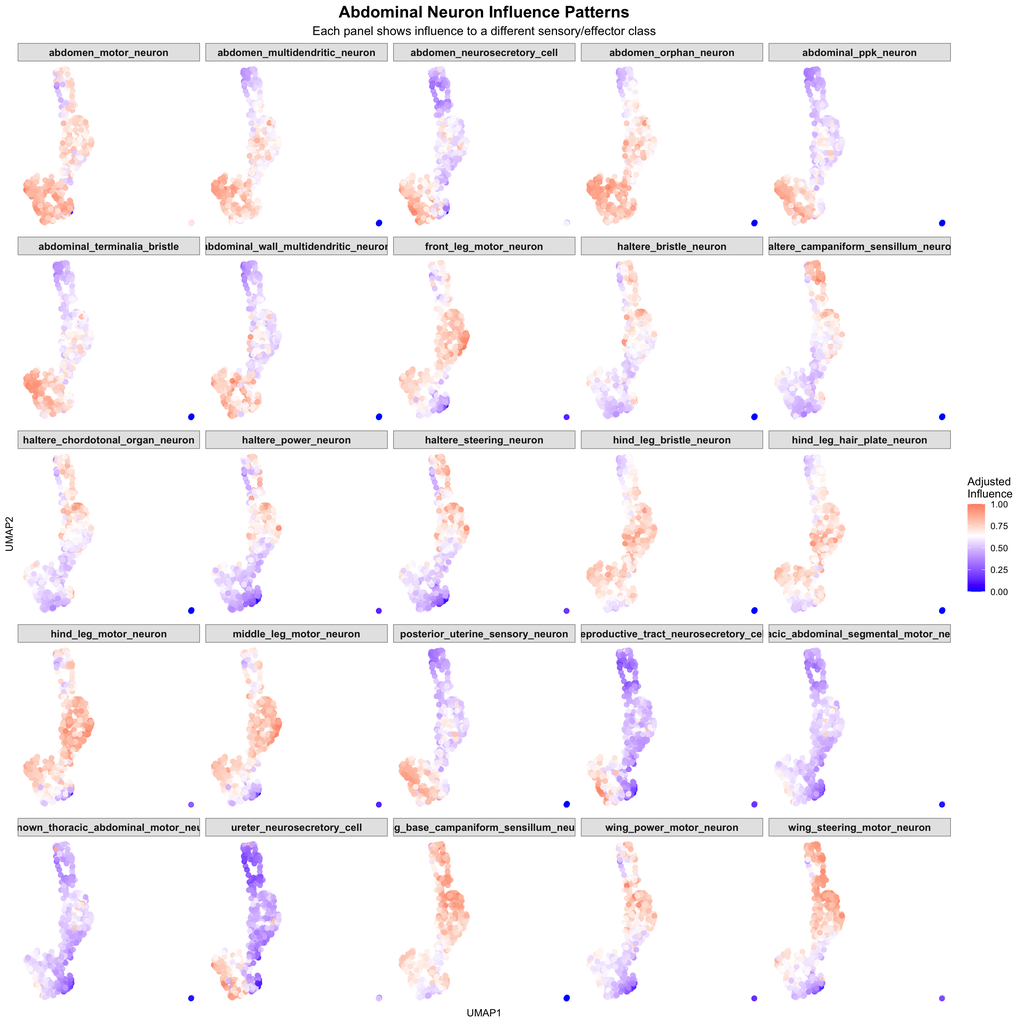

```r
# For each source type, calculate total adjusted influence per abdominal neuron
source_influence_summary <- abdominal_influence_all %>%
  filter(target_sub_class %in% top25_sources) %>%
  group_by(source_type, target_sub_class) %>%
  summarise(
    total_adjusted_influence = sum(adjusted_influence, na.rm = TRUE),
    .groups = "drop"
  )

# Join with UMAP coordinates
# Note: umap_df has source_type as the abdominal types being analyzed
# We need to create a matrix where each row is an abdominal type and columns are the top25 sources
influence_for_plot <- abdominal_influence_all %>%
  filter(target_sub_class %in% top25_sources) %>%
  select(source_type, target_sub_class, adjusted_influence) %>%
  complete(source_type, target_sub_class, fill = list(adjusted_influence = 0)) %>%
  left_join(
    umap_df %>% select(source_type, UMAP1, UMAP2, cluster),
    by = "source_type"
  ) %>%
  filter(!is.na(UMAP1)) %>%
  group_by(target_sub_class) %>%
  mutate(adjusted_influence_minmax = (adjusted_influence-min(adjusted_influence,na.rm=TRUE))/(max(adjusted_influence,na.rm=TRUE)-min(adjusted_influence,na.rm=TRUE))) %>%
  ungroup()

# Create faceted UMAP plot
p_facet_umap <- ggplot(influence_for_plot,
                       aes(x = UMAP1, y = UMAP2, color = adjusted_influence_minmax)) +
  geom_point(size = 2, alpha = 0.8) +
  scale_color_gradient2(
    low = "blue",
    mid = "white",
    high = "red",
    midpoint = median(influence_for_plot$adjusted_influence_minmax, na.rm = TRUE),
    name = "Adjusted\nInfluence"
  ) +
  facet_wrap(~ target_sub_class, ncol = 5) +
  labs(
    title = "Abdominal Neuron Influence Patterns",
    subtitle = "Each panel shows influence to a different sensory/effector class"
  ) +
  theme_minimal() +
  theme(
    plot.title = element_text(face = "bold", size = 16, hjust = 0.5),
    plot.subtitle = element_text(size = 12, hjust = 0.5),
    strip.text = element_text(face = "bold", size = 10),
    strip.background = element_rect(fill = "grey90", color = "grey50"),
    axis.title = element_text(size = 10),
    axis.text = element_blank(),
    axis.ticks = element_blank(),
    panel.grid = element_blank()
  )

save_plot(p_facet_umap, paste0(dataset, "_abdominal_influence_facets"),
          width = 14, height = 14)
print(p_facet_umap)
```

We have successfully decomposed our neurons into potential “functional” modules, which would bear further investigation.

# Summary

In this tutorial, you learned how to:

1. ✓ Calculate indirect connectivity using the influence metric
2. ✓ Set up and use the influencer package
3. ✓ Analyse influence from sensory neurons to dopaminergic neurons
4. ✓ Visualise influence patterns with heatmaps and UMAP
5. ✓ Interpret biological significance of influence scores

The influence metric provides a powerful way to understand how signals propagate through neural circuits beyond direct synaptic connections.